# Predicting Subscribed Users In A Marketing Campaign

## Phase 1: Data Preparation And Visualization

### Group Name: 60

### Names And IDs of Group members:

Vedanth Sujay Prasad, s4041704  
Himanshu Jindal, s3971520  
Pratham Radhakrishna, s3997064

- Introduction
  - Dataset Source
  - Dataset Details
  - Dataset Features
  - Target Feature
- Goals And Objectives
- Data Cleaning and Pre-processing
- Data Exploration and Visualization
- Summary and Conclusion
- References

## Introduction

In today's financial institution scene, direct marketing efforts are critical for engaging new clients and developing long-term connections. Phone-based marketing campaigns have become a common technique for many firms, including Portuguese financial institutions. Among these institutions, the effectiveness of such campaigns is assessed not only by the number of contacts, but also by the conversion of these interactions into tangible outcomes, such as term deposit subscriptions.

The Bank Marketing dataset is a significant data repository that provides insights into the dynamics of a Portuguese financial organization's direct marketing initiatives. This dataset has 21 unique variables and 41,188 entries, capturing a complex tapestry of consumer demographics, marketing information, and subscription results.Moro,S., Rita,P., and Cortez,P.. (2012)

At its heart, the dataset provides a comprehensive perspective of the customer base, including demographic data such as age, marital status, education, home loan status, personal loan status, credit default status, and employment type. These characteristics give a more sophisticated knowledge of the target audience, allowing institutions to successfully customize their marketing efforts to specific sectors of the population.

Furthermore, the dataset delves into the complexities of campaign execution, providing insights into the months with the most and least interactions, the contact types used, the number of workers involved, and key economic indicators like the employment variation rate, consumer price index, and consumer confidence index. Organizations may improve overall campaign performance by evaluating campaign specifics.

The goal variable—subscription status—is central to the dataset. This binary indication indicates if a client has agreed to a term deposit as a result of the marketing effort. Understanding the elements that drive subscription outcomes is critical for financial institutions looking to maximize their marketing ROI and build a loyal client base.

Given its range and depth, the dataset is an invaluable resource for scholars, analysts, and industry practitioners. Using the insights gathered from this dataset, stakeholders may improve prediction models, get actionable knowledge, and drive informed decision-making processes. Thus, the Bank Marketing dataset demonstrates the confluence of data-driven approaches with strategic marketing campaigns, providing insight into the changing landscape of customer interaction and subscription results in the banking industry.

### Dataset Source

The dataset contains data relating to direct marketing campaigns, specifically phone calls, which is conducted by a Portuguese banking institution. The dataset was sourced from UC irvine ML repository(Moro et al. 2014)

### Dataset Details

The Bank Marketing dataset includes information about direct marketing efforts carried out by a Portuguese financial organization. These programs were mostly phone-based and included a number of factors relating to customer demographics and detailed interactions within marketing activities.

**KEY ATTRIBUTES** - **Demographic Information:** Includes age, marital status, education, housing loan status, personal loan status, credit default status and Job Type. - **Campaign Details:** Months of maximum and minimum interactions, Contact type, number of workers, employment variation rate, consumer price index, consumer confidence index. - **Target Variable:** Subscription Status indicates whether or not the client has subscribed to a term deposit.

**Details**

- **Name:** Bank Marketing Dataset
- **Features:** 21 attributes
- **Observations:** 41,188 entries

This information is a significant resource for measuring the success of the bank's marketing initiatives, as well as studying customer behavior and subscription outcomes.

#### Dataset Retrieval

- We read the dataset after saving the csv file in our working directory and loaded the modules required for this report.
- 10 sampled rows are displayed as the dataset contains 41188 rows.

```python
import warnings
warnings.filterwarnings("ignore")

import pandas as pd
import numpy as np
import seaborn as sns
import matplotlib.pyplot as plt

pd.set_option('display.max_columns', None)
```

```python
data = pd.read_csv("Phase1_Group60.csv")
data.head()
```

|  | age | job | marital | education | default | housing | loan | contact | month | day_of_week | duration | campaign | pdays | previous | poutcome | emp.var.rate | cons.price.idx | cons.conf.idx | euribor3m | nr.employed | subscribed |
| --- | --- | --- | --- | --- | --- | --- | --- | --- | --- | --- | --- | --- | --- | --- | --- | --- | --- | --- | --- | --- | --- |
| 0 | 56 | housemaid | married | basic.4y | no | no | no | telephone | may | mon | 261 | 1 | 999 | 0 | nonexistent | 1.1 | 93.994 | -36.4 | 4.857 | 5191.0 | no |
| 1 | 57 | services | married | high.school | unknown | no | no | telephone | may | mon | 149 | 1 | 999 | 0 | nonexistent | 1.1 | 93.994 | -36.4 | 4.857 | 5191.0 | no |
| 2 | 37 | services | married | high.school | no | yes | no | telephone | may | mon | 226 | 1 | 999 | 0 | nonexistent | 1.1 | 93.994 | -36.4 | 4.857 | 5191.0 | no |
| 3 | 40 | admin. | married | basic.6y | no | no | no | telephone | may | mon | 151 | 1 | 999 | 0 | nonexistent | 1.1 | 93.994 | -36.4 | 4.857 | 5191.0 | no |
| 4 | 56 | services | married | high.school | no | no | yes | telephone | may | mon | 307 | 1 | 999 | 0 | nonexistent | 1.1 | 93.994 | -36.4 | 4.857 | 5191.0 | no |

```python
data.tail()
```

|  | age | job | marital | education | default | housing | loan | contact | month | day_of_week | duration | campaign | pdays | previous | poutcome | emp.var.rate | cons.price.idx | cons.conf.idx | euribor3m | nr.employed | subscribed |
| --- | --- | --- | --- | --- | --- | --- | --- | --- | --- | --- | --- | --- | --- | --- | --- | --- | --- | --- | --- | --- | --- |
| 41183 | 73 | retired | married | professional.course | no | yes | no | cellular | nov | fri | 334 | 1 | 999 | 0 | nonexistent | -1.1 | 94.767 | -50.8 | 1.028 | 4963.6 | yes |
| 41184 | 46 | blue-collar | married | professional.course | no | no | no | cellular | nov | fri | 383 | 1 | 999 | 0 | nonexistent | -1.1 | 94.767 | -50.8 | 1.028 | 4963.6 | no |
| 41185 | 56 | retired | married | university.degree | no | yes | no | cellular | nov | fri | 189 | 2 | 999 | 0 | nonexistent | -1.1 | 94.767 | -50.8 | 1.028 | 4963.6 | no |
| 41186 | 44 | technician | married | professional.course | no | no | no | cellular | nov | fri | 442 | 1 | 999 | 0 | nonexistent | -1.1 | 94.767 | -50.8 | 1.028 | 4963.6 | yes |
| 41187 | 74 | retired | married | professional.course | no | yes | no | cellular | nov | fri | 239 | 3 | 999 | 1 | failure | -1.1 | 94.767 | -50.8 | 1.028 | 4963.6 | no |

```python
data.sample(10, random_state=999)
```

|  | age | job | marital | education | default | housing | loan | contact | month | day_of_week | duration | campaign | pdays | previous | poutcome | emp.var.rate | cons.price.idx | cons.conf.idx | euribor3m | nr.employed | subscribed |
| --- | --- | --- | --- | --- | --- | --- | --- | --- | --- | --- | --- | --- | --- | --- | --- | --- | --- | --- | --- | --- | --- |
| 30370 | 59 | admin. | married | high.school | no | yes | no | cellular | apr | thu | 147 | 3 | 999 | 1 | failure | -1.8 | 93.075 | -47.1 | 1.365 | 5099.1 | no |
| 34765 | 38 | technician | single | professional.course | no | yes | no | cellular | may | thu | 306 | 4 | 999 | 0 | nonexistent | -1.8 | 92.893 | -46.2 | 1.266 | 5099.1 | no |
| 14618 | 39 | admin. | divorced | high.school | no | yes | no | cellular | jul | tue | 514 | 5 | 999 | 0 | nonexistent | 1.4 | 93.918 | -42.7 | 4.961 | 5228.1 | yes |
| 5673 | 31 | blue-collar | married | basic.6y | unknown | yes | yes | telephone | may | mon | 161 | 1 | 999 | 0 | nonexistent | 1.1 | 93.994 | -36.4 | 4.857 | 5191.0 | no |
| 37545 | 70 | retired | married | professional.course | no | no | no | cellular | aug | fri | 185 | 3 | 999 | 1 | failure | -2.9 | 92.201 | -31.4 | 0.869 | 5076.2 | no |
| 22715 | 51 | services | married | unknown | no | no | yes | cellular | aug | fri | 135 | 3 | 999 | 0 | nonexistent | 1.4 | 93.444 | -36.1 | 4.964 | 5228.1 | no |
| 32146 | 39 | blue-collar | divorced | basic.9y | no | yes | no | cellular | may | fri | 191 | 1 | 999 | 0 | nonexistent | -1.8 | 92.893 | -46.2 | 1.313 | 5099.1 | no |
| 20213 | 45 | admin. | married | university.degree | no | no | no | cellular | aug | mon | 608 | 1 | 999 | 0 | nonexistent | 1.4 | 93.444 | -36.1 | 4.965 | 5228.1 | yes |
| 20455 | 36 | technician | single | university.degree | unknown | no | no | cellular | aug | tue | 73 | 1 | 999 | 0 | nonexistent | 1.4 | 93.444 | -36.1 | 4.966 | 5228.1 | no |
| 32998 | 40 | services | married | high.school | unknown | yes | no | cellular | may | mon | 182 | 5 | 999 | 0 | nonexistent | -1.8 | 92.893 | -46.2 | 1.299 | 5099.1 | no |

### Dataset Features

```python
from tabulate import tabulate

table = [['Name', 'Data Type', 'Units', 'Brief description'],
        ['age', 'Numeric','Years', 'Age of the customer'],
        ['job', 'Nominal categorical', 'NA', 'Category of job the customer belongs to'],
        ['marital', 'Nominal categorical','NA', 'Marital status of customer'],
        ['education', 'Ordinal categorical','NA', 'Education level of customer'],
        ['default', 'Nominal categorical data','NA', 'Default credit status of customer'],
        ['housing', 'Nominal categorical data', 'NA', 'Housing loan status'],
        ['contact', 'Nominal categorical data','NA', 'Type of contact'],
        ['month', 'Ordinal categorical data','NA', 'Month of the year'],
        ['day_of_week', 'Nominal categorical data','NA', 'Day of the week'],
        ['loan', 'Nominal categorical', 'NA', 'Does the person have a loan?'],
        ['duration', 'Numeric', 'Seconds', 'Duration of last contact'],
        ['campaign', 'Numeric', 'NA', 'Number of contact performed during this campaign'],
        ['pdays', 'Numeric', 'NA', 'Number of days after last contact'],
        ['previous', 'Numeric', 'NA', 'Number of contacts performed before this campaign'],
        ['poutcome', 'Nominal categorical', 'NA', 'Outcome of previous marketing campaign'],
        ['emp.var.rate', 'Numeric', 'NA', 'Employment change rate for 3 months'],
        ['cons.price.idx', 'Numeric', 'NA', 'Monthly consumer price index'],
        ['cons.conf.idx', 'Numeric', 'NA', 'Monthly confidence index'],
        ['euribor3m', 'Numeric', 'NA', 'It is the rate at which money is lent in Europe'],
        ['nr.employed', 'Numeric', 'NA', 'Number of employees quarterly indicator'],
        ['subscribed', 'Nominal categorical', 'NA', 'Client subscribed or not']
        ]

print(tabulate(table, headers='firstrow', tablefmt='fancy_grid'))
```

```
╒════════════════╤══════════════════════════╤═════════╤═══════════════════════════════════════════════════╕
│ Name           │ Data Type                │ Units   │ Brief description                                 │
╞════════════════╪══════════════════════════╪═════════╪═══════════════════════════════════════════════════╡
│ age            │ Numeric                  │ Years   │ Age of the customer                               │
├────────────────┼──────────────────────────┼─────────┼───────────────────────────────────────────────────┤
│ job            │ Nominal categorical      │ NA      │ Category of job the customer belongs to           │
├────────────────┼──────────────────────────┼─────────┼───────────────────────────────────────────────────┤
│ marital        │ Nominal categorical      │ NA      │ Marital status of customer                        │
├────────────────┼──────────────────────────┼─────────┼───────────────────────────────────────────────────┤
│ education      │ Ordinal categorical      │ NA      │ Education level of customer                       │
├────────────────┼──────────────────────────┼─────────┼───────────────────────────────────────────────────┤
│ default        │ Nominal categorical data │ NA      │ Default credit status of customer                 │
├────────────────┼──────────────────────────┼─────────┼───────────────────────────────────────────────────┤
│ housing        │ Nominal categorical data │ NA      │ Housing loan status                               │
├────────────────┼──────────────────────────┼─────────┼───────────────────────────────────────────────────┤
│ contact        │ Nominal categorical data │ NA      │ Type of contact                                   │
├────────────────┼──────────────────────────┼─────────┼───────────────────────────────────────────────────┤
│ month          │ Ordinal categorical data │ NA      │ Month of the year                                 │
├────────────────┼──────────────────────────┼─────────┼───────────────────────────────────────────────────┤
│ day_of_week    │ Nominal categorical data │ NA      │ Day of the week                                   │
├────────────────┼──────────────────────────┼─────────┼───────────────────────────────────────────────────┤
│ loan           │ Nominal categorical      │ NA      │ Does the person have a loan?                      │
├────────────────┼──────────────────────────┼─────────┼───────────────────────────────────────────────────┤
│ duration       │ Numeric                  │ Seconds │ Duration of last contact                          │
├────────────────┼──────────────────────────┼─────────┼───────────────────────────────────────────────────┤
│ campaign       │ Numeric                  │ NA      │ Number of contact performed during this campaign  │
├────────────────┼──────────────────────────┼─────────┼───────────────────────────────────────────────────┤
│ pdays          │ Numeric                  │ NA      │ Number of days after last contact                 │
├────────────────┼──────────────────────────┼─────────┼───────────────────────────────────────────────────┤
│ previous       │ Numeric                  │ NA      │ Number of contacts performed before this campaign │
├────────────────┼──────────────────────────┼─────────┼───────────────────────────────────────────────────┤
│ poutcome       │ Nominal categorical      │ NA      │ Outcome of previous marketing campaign            │
├────────────────┼──────────────────────────┼─────────┼───────────────────────────────────────────────────┤
│ emp.var.rate   │ Numeric                  │ NA      │ Employment change rate for 3 months               │
├────────────────┼──────────────────────────┼─────────┼───────────────────────────────────────────────────┤
│ cons.price.idx │ Numeric                  │ NA      │ Monthly consumer price index                      │
├────────────────┼──────────────────────────┼─────────┼───────────────────────────────────────────────────┤
│ cons.conf.idx  │ Numeric                  │ NA      │ Monthly confidence index                          │
├────────────────┼──────────────────────────┼─────────┼───────────────────────────────────────────────────┤
│ euribor3m      │ Numeric                  │ NA      │ It is the rate at which money is lent in Europe   │
├────────────────┼──────────────────────────┼─────────┼───────────────────────────────────────────────────┤
│ nr.employed    │ Numeric                  │ NA      │ Number of employees quarterly indicator           │
├────────────────┼──────────────────────────┼─────────┼───────────────────────────────────────────────────┤
│ subscribed     │ Nominal categorical      │ NA      │ Client subscribed or not                          │
╘════════════════╧══════════════════════════╧═════════╧═══════════════════════════════════════════════════╛
```

### Target Feature

For this project, the target feature in this dataset will be the subscribed users to the banking institution. The number of subscribed users will be predicted based on the explanatory/ descriptive values.

## Goals and Objectives

Goals:

1. Optimize Marketing Strategies:Use demographic and campaign data insights to enhance marketing efforts, increasing subscription rates and maximizing ROI.
2. Enhance Customer Targeting:Create a more targeted strategy to customer marketing by identifying important demographic categories who are more likely to sign up for the term deposit.
3. Improve Campaign Efficiency:Simplify campaign efforts by determining the best communication channels, months, and days of the week to engage potential clients.
4. Mitigate Risk of Default:Analyze default credit status trends to reduce the probability of default among customers, resulting in a healthier portfolio and lower financial losses.

Objectives:

1. Segment Customers: Use demographic variables such as age, marital status, education, and work type to design marketing efforts to specific client profiles.
2. Evaluate Campaign Performance: Analyze subscription rates over different months, days of the week, and contact techniques to assess the effectiveness of previous marketing efforts.
3. Identify Key Factors: Determine the elements that influence subscription behavior, such as economic indicators (e.g., employment fluctuation rate, consumer price index) and customer confidence levels.
4. Refine Targeting Criteria: Use data like default credit status, housing loan status, and personal loan status to focus efforts on clients who are more likely to subscribe.
5. Implement Data-Driven Strategies: To boost customer engagement and retention, use predictive modeling approaches to anticipate subscription likelihood and tailor marketing messaging.
6. Monitor and Adjust: Continuously assess campaign results and consumer responses, and alter plans as needed to respond to changing market dynamics and customer preferences.

By establishing these goals and objectives, the purpose is to provide actionable insights from dataset analysis and lead strategic decision-making in order to achieve marketing success and growth.Ahmed Mohamed Zaki, Nima Khodadadi, Wei Hong Lim, S. K. Towfek. (2024)

## Data Cleaning and Preprocessing

In this section, we describe the data cleaning and preprocessing steps undertaken for this project.

### Data Cleaning Steps

Let's start by displaying all of the columns in our dataset.

```python
data.columns
```

```
Index(['age', 'job', 'marital', 'education', 'default', 'housing', 'loan',
       'contact', 'month', 'day_of_week', 'duration', 'campaign', 'pdays',
       'previous', 'poutcome', 'emp.var.rate', 'cons.price.idx',
       'cons.conf.idx', 'euribor3m', 'nr.employed', 'subscribed'],
      dtype='object')
```

```python
data.columns = data.columns.str.lower().str.strip()

columns_mapping = {
    'euribor3m': 'euribor_3m',
    'emp.var.rate': 'emp_var_rate',
    'cons.price.idx': 'cons_price_idx',
    'cons.conf.idx': 'cons_conf_idx',
    'nr.employed': 'nr_employed'
}

# Renaming the columns
data = data.rename(columns = columns_mapping)
```

We are improving the structure of our dataset's column names to maintain uniformity and clarity. First, we convert all column names to lowercase and eliminate any leading or trailing whitespace. This phase standardizes the format for all column names, minimizing any conflicts during data manipulation.

We next build a mapping dictionary called columns_mapping, which specifies the modifications we want to make to individual columns. For example, we are changing column names like 'euribor3m' to 'euribor_3m' and 'emp.var.rate' to 'emp_var_rate' to align them with a more uniform and legible structure.

Finally, we use the rename() method to rename the columns based on the mappings specified in columns_mapping. By running this code, we simplify the column names in our dataset, improving clarity and allowing for easier data analysis and modeling operations.

Now we examine the data types and ensure that they match the anticipated data types, thus no changes are required here.

```python
# Checking for data types
print(f"Shape of the dataset = {data.shape}\n")
print(f"Data types are given below in which 'object' indicates a string type: ")
print(data.dtypes)
```

```
Shape of the dataset = (41188, 21)

Data types are given below in which 'object' indicates a string type:
age                 int64
job                object
marital            object
education          object
default            object
housing            object
loan               object
contact            object
month              object
day_of_week        object
duration            int64
campaign            int64
pdays               int64
previous            int64
poutcome           object
emp_var_rate      float64
cons_price_idx    float64
cons_conf_idx     float64
euribor_3m        float64
nr_employed       float64
subscribed         object
dtype: object
```

```python
data.describe(include='object').T
```

|  | count | unique | top | freq |
| --- | --- | --- | --- | --- |
| job | 41188 | 12 | admin. | 10422 |
| marital | 41188 | 4 | married | 24928 |
| education | 41188 | 8 | university.degree | 12168 |
| default | 41188 | 3 | no | 32588 |
| housing | 41188 | 3 | yes | 21576 |
| loan | 41188 | 3 | no | 33950 |
| contact | 41188 | 2 | cellular | 26144 |
| month | 41188 | 10 | may | 13769 |
| day_of_week | 41188 | 5 | thu | 8623 |
| poutcome | 41188 | 3 | nonexistent | 35563 |
| subscribed | 41188 | 2 | no | 36548 |

```python
# To see all unique values in categorical data types

categorical_columns = data.columns[data.dtypes==object].tolist()

for col in categorical_columns:
    print('Unique values for ' + col)
    print(data[col].unique())
    print('')
```

```
Unique values for job
['housemaid' 'services' 'admin.' 'blue-collar' 'technician' 'retired'
 'management' 'unemployed' 'self-employed' 'unknown' 'entrepreneur'
 'student']

Unique values for marital
['married' 'single' 'divorced' 'unknown']

Unique values for education
['basic.4y' 'high.school' 'basic.6y' 'basic.9y' 'professional.course'
 'unknown' 'university.degree' 'illiterate']

Unique values for default
['no' 'unknown' 'yes']

Unique values for housing
['no' 'yes' 'unknown']

Unique values for loan
['no' 'yes' 'unknown']

Unique values for contact
['telephone' 'cellular']

Unique values for month
['may' 'jun' 'jul' 'aug' 'oct' 'nov' 'dec' 'mar' 'apr' 'sep']

Unique values for day_of_week
['mon' 'tue' 'wed' 'thu' 'fri']

Unique values for poutcome
['nonexistent' 'failure' 'success']

Unique values for subscribed
['no' 'yes']
```

```python
data.describe(include=['int64', 'float64']).T
```

|  | count | mean | std | min | 25% | 50% | 75% | max |
| --- | --- | --- | --- | --- | --- | --- | --- | --- |
| age | 41188.0 | 40.024060 | 10.421250 | 17.000 | 32.000 | 38.000 | 47.000 | 98.000 |
| duration | 41188.0 | 258.285010 | 259.279249 | 0.000 | 102.000 | 180.000 | 319.000 | 4918.000 |
| campaign | 41188.0 | 2.567593 | 2.770014 | 1.000 | 1.000 | 2.000 | 3.000 | 56.000 |
| pdays | 41188.0 | 962.475454 | 186.910907 | 0.000 | 999.000 | 999.000 | 999.000 | 999.000 |
| previous | 41188.0 | 0.172963 | 0.494901 | 0.000 | 0.000 | 0.000 | 0.000 | 7.000 |
| emp_var_rate | 41188.0 | 0.081886 | 1.570960 | -3.400 | -1.800 | 1.100 | 1.400 | 1.400 |
| cons_price_idx | 41188.0 | 93.575664 | 0.578840 | 92.201 | 93.075 | 93.749 | 93.994 | 94.767 |
| cons_conf_idx | 41188.0 | -40.502600 | 4.628198 | -50.800 | -42.700 | -41.800 | -36.400 | -26.900 |
| euribor_3m | 41188.0 | 3.621291 | 1.734447 | 0.634 | 1.344 | 4.857 | 4.961 | 5.045 |
| nr_employed | 41188.0 | 5167.035911 | 72.251528 | 4963.600 | 5099.100 | 5191.000 | 5228.100 | 5228.100 |

```python
# Checking for missing values
print(f"\nNumber of missing values for each column/feature: ")
print(data.isnull().sum())
```

```
Number of missing values for each column/feature:
age               0
job               0
marital           0
education         0
default           0
housing           0
loan              0
contact           0
month             0
day_of_week       0
duration          0
campaign          0
pdays             0
previous          0
poutcome          0
emp_var_rate      0
cons_price_idx    0
cons_conf_idx     0
euribor_3m        0
nr_employed       0
subscribed        0
dtype: int64
```

```python
data["emp_var_rate"].value_counts().sort_index()
```

```
-3.4     1071
-3.0      172
-2.9     1663
-1.8     9184
-1.7      773
-1.1      635
-0.2       10
-0.1     3683
 1.1     7763
 1.4    16234
Name: emp_var_rate, dtype: int64
```

- Employment change rate for 3 months indicator is:
1. Minimum = -3.4
2. Maximum = 1.4

```python
data["cons_price_idx"].value_counts().sort_index()
```

```
92.201     770
92.379     267
92.431     447
92.469     178
92.649     357
92.713     172
92.756      10
92.843     282
92.893    5794
92.963     715
93.075    2458
93.200    3616
93.369     264
93.444    5175
93.749     174
93.798      67
93.876     212
93.918    6685
93.994    7763
94.027     233
94.055     229
94.199     303
94.215     311
94.465    4374
94.601     204
94.767     128
Name: cons_price_idx, dtype: int64
```

- Monthly consumer price index(cons.price.idx) is:
1. Minimum = 92.201
2. Maximum = 94.767

```python
data["cons_conf_idx"].value_counts().sort_index()
```

```
-50.8     128
-50.0     282
-49.5     204
-47.1    2458
-46.2    5794
-45.9      10
-42.7    6685
-42.0    3616
-41.8    4374
-40.8     715
-40.4      67
-40.3     311
-40.0     212
-39.8     229
-38.3     233
-37.5     303
-36.4    7763
-36.1    5175
-34.8     264
-34.6     174
-33.6     178
-33.0     172
-31.4     770
-30.1     357
-29.8     267
-26.9     447
Name: cons_conf_idx, dtype: int64
```

- Monthly consumer confidence index(cons.conf.idx) is:
1. Minimum = -50.8
2. Maximum = -26.9

```python
data["euribor_3m"].value_counts().sort_values()
```

```
3.669       1
3.329       1
3.053       1
3.282       1
3.488       1
         ...
4.856    1210
4.961    1902
4.963    2487
4.962    2613
4.857    2868
Name: euribor_3m, Length: 316, dtype: int64
```

- Euribor - It is the rate at which credit institutions lend money to each other in Europe. It is a 3 month indicator.

```python
data["nr_employed"].value_counts().sort_index()
```

```
4963.6      635
4991.6      773
5008.7      650
5017.5     1071
5023.5      172
5076.2     1663
5099.1     8534
5176.3       10
5191.0     7763
5195.8     3683
5228.1    16234
Name: nr_employed, dtype: int64
```

- Number of employees (nr.employed) in a quarterly indicator:
1. Minumum = 4963.600
2. Maximum = 5228.100

```python
data["default"].value_counts().sort_values()
```

```
yes            3
unknown     8597
no         32588
Name: default, dtype: int64
```

- The default credit status of employees

```python
data["education"].value_counts().sort_values()
```

```
illiterate                18
unknown                 1731
basic.6y                2292
basic.4y                4176
professional.course     5243
basic.9y                6045
high.school             9515
university.degree      12168
Name: education, dtype: int64
```

- The number of customers according to their education level. It consists of 8 different categories based on their education levels.
1. 12168 customers have a university degree.
2. 9515 customers have a high-school diploma.
3. 6045 have 9 years of basic education.
4. 5243 have taken a professional course.
5. 4176 have 4 years of basic education.
6. 2292 have 6 years of basic education.
7. 1731 customers education status is unknown.
8. 18 customers belong to the "iliterate" status.

```python
data["marital"].value_counts()
```

```
married     24928
single      11568
divorced     4612
unknown        80
Name: marital, dtype: int64
```

- The number of customers according to marital status:
1. Married - 24928 people
2. Single - 11568 people
3. Divorced - 4612
4. Unknown status - 80

```python
data["job"].value_counts().sort_values()
```

```
unknown            330
student            875
unemployed        1014
housemaid         1060
self-employed     1421
entrepreneur      1456
retired           1720
management        2924
services          3969
technician        6743
blue-collar       9254
admin.           10422
Name: job, dtype: int64
```

- The number of customers with top occupations are:
1. Administrator jobs - 10422
2. Blue-collar jobs - 9254
3. Technician - 6743

```python
data["loan"].value_counts()
```

```
no         33950
yes         6248
unknown      990
Name: loan, dtype: int64
```

- Number of customers in 3 different categories eligible for a loan (Yes/No/Unknown)
1. Yes - 6248
2. No - 33950
3. Unknown - 990

```python
data["housing"].value_counts()
```

```
yes        21576
no         18622
unknown      990
Name: housing, dtype: int64
```

- Number of houses in 3 different categories for housing loan status:
1. Yes - 21576 houses on loan
2. No - 18622 houses not on loan
3. Unknown - 990

```python
data["contact"].value_counts()
```

```
cellular     26144
telephone    15044
Name: contact, dtype: int64
```

```python
data["month"].value_counts().sort_values()
```

```
dec      182
mar      546
sep      570
oct      718
apr     2632
nov     4101
jun     5318
aug     6178
jul     7174
may    13769
Name: month, dtype: int64
```

- December shows least number of customer contacts with 182.
- May shows maximum number of customer contacts with 13769.

```python
data["day_of_week"].value_counts().sort_values()
```

```
fri    7827
tue    8090
wed    8134
mon    8514
thu    8623
Name: day_of_week, dtype: int64
```

```python
data["poutcome"].value_counts()
```

```
nonexistent    35563
failure         4252
success         1373
Name: poutcome, dtype: int64
```

- The success rate of the campaign of the banking institution.

```python
data["subscribed"].value_counts()
```

```
no     36548
yes     4640
Name: subscribed, dtype: int64
```

- Subscription status of customers

```python
cat_list = []
num_list = []

for column_name in data.columns:
    unique_val = len(data[column_name].unique())
    if unique_val<13:
        cat_list.append(column_name)
    else:
        num_list.append(column_name)
```

```python
cat_list
```

```
['job',
 'marital',
 'education',
 'default',
 'housing',
 'loan',
 'contact',
 'month',
 'day_of_week',
 'previous',
 'poutcome',
 'emp_var_rate',
 'nr_employed',
 'subscribed']
```

```python
num_list
```

```
['age',
 'duration',
 'campaign',
 'pdays',
 'cons_price_idx',
 'cons_conf_idx',
 'euribor_3m']
```

**Box Plot**

We're using Seaborn's boxplot function to create a boxplot of the dataset's 'age' column. The plt.figure(figsize=(15, 8)) function sets the figure's width and height to 15 inches and 8 inches, respectively.

The boxplot is a graphical depiction of the data distribution, including the median, quartiles, and any outliers. Figure 1 is a graphic designed to identify any outliers in the age data.

Outliers, if present, can have a substantial influence on the statistical analysis and modeling process, hence it is critical to discover and manage them properly. By visualizing the age distribution in this manner, we obtain insight into its spread and any potential abnormalities that may necessitate additional inquiry or treatment.

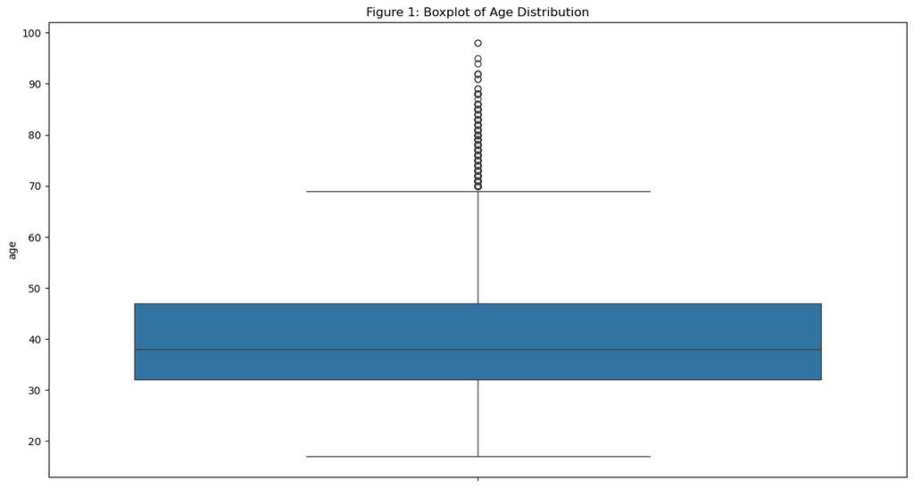

```python
plt.figure(figsize = (15,8))
sns.boxplot(data['age'])
plt.title('Figure 1: Boxplot of Age Distribution')
plt.show() # Checking for outliers
```

This boxplot depicts the distribution of ages in the dataset. Outliers, shown by dots beyond the top whisker, are present in people above the age of 70.

In this boxplot, we can see that the top whisker extends from approximately the age of 70, indicating the possibility of outliers exceeding the age distribution's upper bound. These outliers indicate that there are people whose ages are much older than the average of the sample.

We are conducting outlier detection on numerical columns to identify any values that significantly deviate from the dataset's distribution.

This visualization identifies probable abnormalities in the age distribution that may require more research or preprocessing procedures in later studies.

```python
for i in data.loc[:, num_list]:
    Q1 = data[i].quantile(0.25)
    Q3 = data[i].quantile(0.75)
    IQR = Q3 - Q1
    up = Q3 + 1.5*IQR
    low = Q1 - 1.5*IQR

    if data[(data[i]>up) | (data[i] <low)].any(axis=None):
        print(i, "yes")
    else:
        print(i, "no")
```

```
age yes
duration yes
campaign yes
pdays yes
cons_price_idx no
cons_conf_idx yes
euribor_3m no
```

```python
data.describe().T
```

|  | count | mean | std | min | 25% | 50% | 75% | max |
| --- | --- | --- | --- | --- | --- | --- | --- | --- |
| age | 41188.0 | 40.024060 | 10.421250 | 17.000 | 32.000 | 38.000 | 47.000 | 98.000 |
| duration | 41188.0 | 258.285010 | 259.279249 | 0.000 | 102.000 | 180.000 | 319.000 | 4918.000 |
| campaign | 41188.0 | 2.567593 | 2.770014 | 1.000 | 1.000 | 2.000 | 3.000 | 56.000 |
| pdays | 41188.0 | 962.475454 | 186.910907 | 0.000 | 999.000 | 999.000 | 999.000 | 999.000 |
| previous | 41188.0 | 0.172963 | 0.494901 | 0.000 | 0.000 | 0.000 | 0.000 | 7.000 |
| emp_var_rate | 41188.0 | 0.081886 | 1.570960 | -3.400 | -1.800 | 1.100 | 1.400 | 1.400 |
| cons_price_idx | 41188.0 | 93.575664 | 0.578840 | 92.201 | 93.075 | 93.749 | 93.994 | 94.767 |
| cons_conf_idx | 41188.0 | -40.502600 | 4.628198 | -50.800 | -42.700 | -41.800 | -36.400 | -26.900 |
| euribor_3m | 41188.0 | 3.621291 | 1.734447 | 0.634 | 1.344 | 4.857 | 4.961 | 5.045 |
| nr_employed | 41188.0 | 5167.035911 | 72.251528 | 4963.600 | 5099.100 | 5191.000 | 5228.100 | 5228.100 |

```python
out_list = ["age", "duration"]
```

```python
for i in data.loc[:, out_list]:
    Q1 = data[i].quantile(0.25)
    Q3 = data[i].quantile(0.75)
    IQR = Q3 - Q1
    up_lim = Q3 + 1.5*IQR
    low_lim = Q1 - 1.5*IQR
    data.loc[data[i]>up_lim,i] = up_lim
    data.loc[data[i]<low_lim,i] = low_lim
```

```python
for i in data.loc[:, num_list]:
    Q1 = data[i].quantile(0.25)
    Q3 = data[i].quantile(0.75)
    IQR = Q3 - Q1
    up = Q3 + 1.5*IQR
    low = Q1 - 1.5*IQR

    if data[(data[i]>up) | (data[i] <low)].any(axis=None):
        print(i, "yes")
    else:
        print(i, "no")
```

```
age no
duration no
campaign yes
pdays yes
cons_price_idx no
cons_conf_idx yes
euribor_3m no
```

```python
# Function to detect and handle outliers using IQR
def handle_outliers_iqr(data, column):
    Q1 = data[column].quantile(0.25)
    Q3 = data[column].quantile(0.75)
    IQR = Q3 - Q1
    lower_bound = Q1 - 1.5 * IQR
    upper_bound = Q3 + 1.5 * IQR
    # Filter outliers
    outliers = data[(data[column] < lower_bound) | (data[column] > upper_bound)]
    # Replace outliers with median
    data[column] = np.where((data[column] < lower_bound) | (data[column] > upper_bound), data[column].median(), data[column])
    return data, outliers

# Apply the function to handle outliers for numerical columns
numerical_columns = data.select_dtypes(include=np.number).columns
outliers_info = {}
for column in numerical_columns:
    data, outliers = handle_outliers_iqr(data, column)
    outliers_info[column] = outliers

# Print information about handled outliers
print("Outliers handled using IQR method:")
for column, outliers in outliers_info.items():
    print(f"Column: {column}, Number of Outliers Detected: {len(outliers)}")
```

```
Outliers handled using IQR method:
Column: age, Number of Outliers Detected: 0
Column: duration, Number of Outliers Detected: 0
Column: campaign, Number of Outliers Detected: 2406
Column: pdays, Number of Outliers Detected: 1515
Column: previous, Number of Outliers Detected: 5625
Column: emp_var_rate, Number of Outliers Detected: 0
Column: cons_price_idx, Number of Outliers Detected: 0
Column: cons_conf_idx, Number of Outliers Detected: 447
Column: euribor_3m, Number of Outliers Detected: 0
Column: nr_employed, Number of Outliers Detected: 0
```

```python
data.describe().T
```

|  | count | mean | std | min | 25% | 50% | 75% | max |
| --- | --- | --- | --- | --- | --- | --- | --- | --- |
| age | 41188.0 | 39.939485 | 10.129367 | 17.000 | 32.000 | 38.000 | 47.000 | 69.500 |
| duration | 41188.0 | 234.997317 | 177.353309 | 0.000 | 102.000 | 180.000 | 319.000 | 644.500 |
| campaign | 41188.0 | 2.041614 | 1.242362 | 1.000 | 1.000 | 2.000 | 3.000 | 6.000 |
| pdays | 41188.0 | 999.000000 | 0.000000 | 999.000 | 999.000 | 999.000 | 999.000 | 999.000 |
| previous | 41188.0 | 0.000000 | 0.000000 | 0.000 | 0.000 | 0.000 | 0.000 | 0.000 |
| emp_var_rate | 41188.0 | 0.081886 | 1.570960 | -3.400 | -1.800 | 1.100 | 1.400 | 1.400 |
| cons_price_idx | 41188.0 | 93.575664 | 0.578840 | 92.201 | 93.075 | 93.749 | 93.994 | 94.767 |
| cons_conf_idx | 41188.0 | -40.664305 | 4.405021 | -50.800 | -42.700 | -41.800 | -36.400 | -29.800 |
| euribor_3m | 41188.0 | 3.621291 | 1.734447 | 0.634 | 1.344 | 4.857 | 4.961 | 5.045 |
| nr_employed | 41188.0 | 5167.035911 | 72.251528 | 4963.600 | 5099.100 | 5191.000 | 5228.100 | 5228.100 |

## Data Exploration and Visualisation

Our Dataset is now clean and ready for visualization and exploring of each of the features.

### Bar Chart Of Job

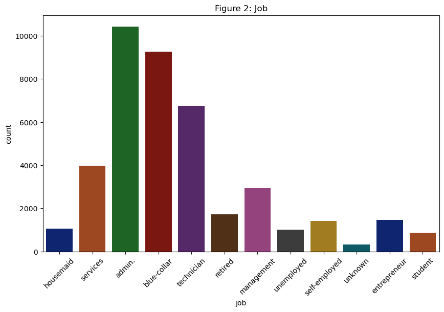

```python
plt.figure(figsize=(10, 6))
sns.countplot(x = 'job', data = data, palette = 'dark')
plt.xticks(rotation=45)
plt.title('Figure 2: Job')
```

The countplot depicts the distribution of various employment categories in the dataset. Each bar reflects the number of people affiliated with a certain employment type.

The visualization offers a clear overview of the distribution of job categories within the dataset, showing the frequency of specific occupations and allowing for insights into the sample population's demographics.

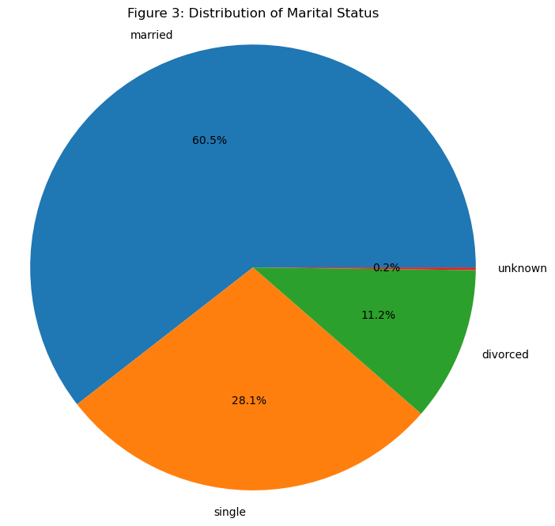

```python
# Pie chart illustrating the distribution of marital status
plt.figure(figsize=(8, 8))
marital_counts = data['marital'].value_counts()
plt.pie(marital_counts, labels=marital_counts.index, autopct='%1.1f%%')
plt.title('Figure 3: Distribution of Marital Status')
plt.axis('equal')
plt.show()
```

The pie chart depicts the distribution of marital status categories within the dataset. Each segment of the pie represents a particular marital status category, with the size of the segment proportional to the number of people in that group.

The biggest part of the pie is labeled "married," accounting for around 60.5% of the dataset. This suggests that the majority of people in the sample are married.

The next biggest section, labeled "single," accounts for around 28.1% of the dataset. This represents a sizable proportion of people who are not currently married.

The "divorced" group accounts for around 11.2% of the dataset, demonstrating a lesser but still significant number of those who have divorced.

Finally, the smallest section labeled "unknown" accounts for only 0.2% of the sample, demonstrating that a very tiny number of individuals do not have marital status information accessible.

Overall, the pie chart gives a clear visual depiction of the distribution of married status categories, allowing for insight into the dataset's marital demography.

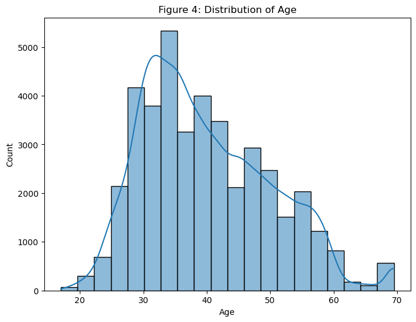

```python
plt.figure(figsize=(8, 6))
sns.histplot(data=data, x='age', bins=20, kde=True)
plt.title('Figure 4: Distribution of Age')
plt.xlabel('Age')
plt.ylabel('Count')
plt.show()
```

The histogram depicts the distribution of ages in the dataset, with each bar indicating a range of ages and the height of the bar equal to the number of people falling inside that range.

The highest bar in the histogram is seen in the age range of 32 to 35, with around 5,400 people falling into this category. This suggests a peak in the distribution for this age group.

Following that, the next greatest bars are in the age ranges of 28 to 30 (about 4,100 people) and 38 to 40 (just under 4,000 people), showing that considerable chunks of the dataset fall into these age categories.

Other prominent peaks in the histogram include age ranges 30 to 32, 40 to 42, 36 to 38, 45 to 49, and 50, each with a different number of participants.

Overall, the histogram depicts the age distribution within the dataset, allowing for insights on the demographic makeup and age trends of the sampled population.

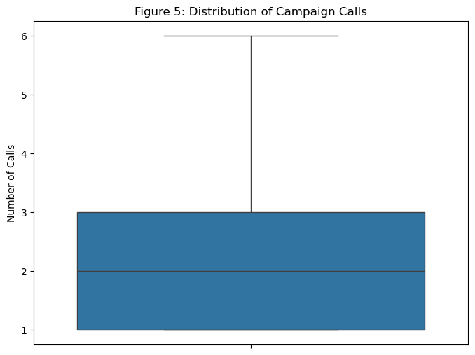

```python
plt.figure(figsize=(8, 6))
sns.boxplot(data=data, y='campaign')
plt.title('Figure 5: Distribution of Campaign Calls')
plt.ylabel('Number of Calls')
plt.show()
```

The boxplot illustrates the distribution of the number of campaign calls made to individuals in the dataset. It displays crucial statistical parameters including the median, quartiles, and probable outliers.

The boxplot's upper bound extends to 6, suggesting that the dataset contains a maximum of six campaign calls. Furthermore, there are no outliers above the upper bound, indicating that the distribution of campaign calls has no extreme values.

The box in the plot reflects the interquartile range (IQR), whereas the main line represents the median number of campaign calls. In this scenario, the median is set to 2, suggesting that half of the respondents got two or fewer campaign calls.

The width of the box (ranging from 1 to 3) contains the bulk of the data, implying that most campaign calls fell within this range for most people.

Overall, the boxplot summarizes the distribution of campaign calls in a straightforward manner, making it easy to identify central tendency and variability within the dataset.

[output not shown]

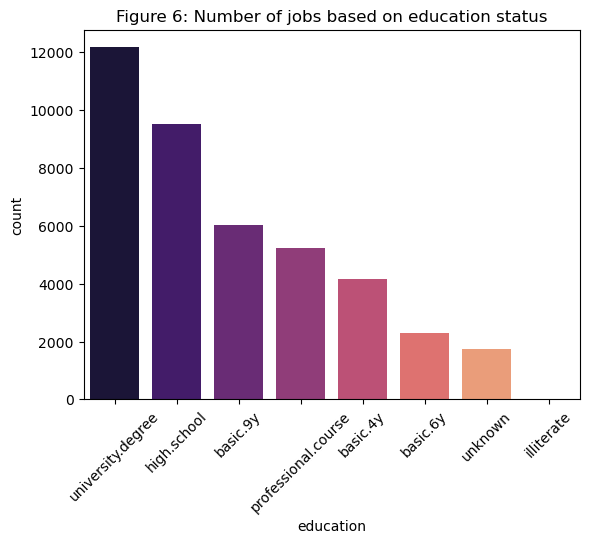

```python
plt.figure()
sns.countplot(x = 'education', data = data, palette = 'magma', order = data['education'].value_counts().index)
plt.title("Figure 6: Number of jobs based on education status")
plt.xticks(rotation=45)
```

The countplot depicts the distribution of employment counts across various education statuses in the dataset. Each bar reflects the number of employment connected with a specific educational status group.

Individuals with a university degree have the greatest bar in the countplot, accounting for nearly 12,000 employment. This suggests that a sizable fraction of those in the sample with a university degree are employed.

The next highest bar is set for persons with a high school diploma, with around 9,500 positions available in this group.

Other significant bars include those with a basic.9y education status (roughly 6,000 jobs), professional.course education status (approximately 5,100 jobs), basic.4y education status (about 4,100 jobs), and basic.6y and unknown education statuses.

Overall, the countplot depicts the distribution of job counts across different education status groups, providing insights into employment patterns among people with diverse educational backgrounds.

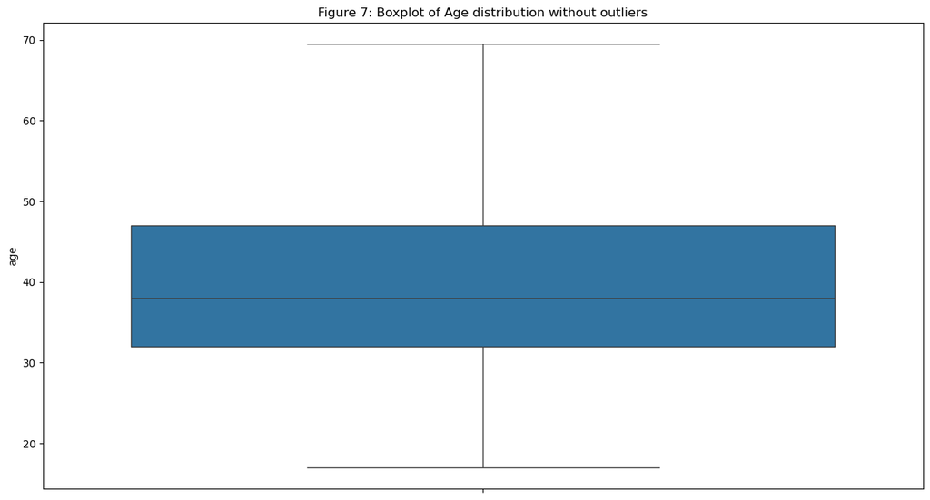

```python
plt.figure(figsize = (15,8))
sns.boxplot(data['age'])
plt.title("Figure 7: Boxplot of Age distribution without outliers")
plt.xticks(rotation=45)
plt.show()
```

The boxplot shows the distribution of ages within the dataset, omitting outliers. It includes crucial statistical variables including the median, quartiles, and the lack of outliers.

The blue rectangular box on the y-axis ranges from around 31 to 47, representing the age distribution's interquartile range (IQR). The center line in the box reflects the median age, which is around 38 years.

Importantly, the age distribution has no outliers, as seen by the absence of any dots outside the boxplot's whiskers. This means that the age data has no extreme values or abnormalities that might distort the distribution.

Overall, the boxplot gives a simple description of the age distribution in the dataset, allowing for insights into the central tendency and variability of ages among the sampled population.

### Bivariate Visualization

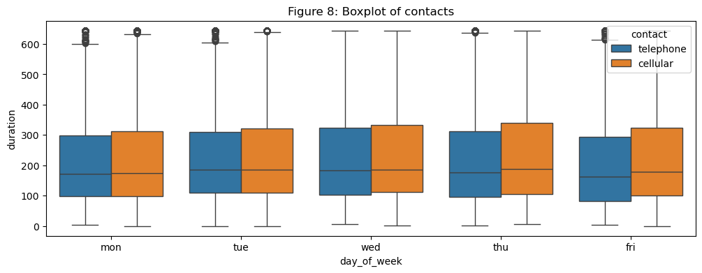

```python
plt.figure(figsize=(12, 4))
plt.title("Figure 8: Boxplot of contacts")
sns.boxplot(x = 'day_of_week', y = 'duration', data = data, hue='contact')
```

The boxplot depicts the distribution of contact durations for each day of the week, organized by contact type (telephone or cellular). It gives information on the variability and central tendency of contact durations across different days and contact techniques.

On each day of the week:

Mondays phone calls typically last between 100 and 300 seconds, with outliers exceeding 600. Cellular connections last from 100 to 310 seconds, with fewer outliers than telephone calls. The median time for combined telephone and cellular interactions is around 175 seconds.

Tuesday Telephone interactions last between 110 and 300 seconds, with outliers exceeding the top bound (600). Cellular interactions last 110 to 315 seconds, with fewer outliers than telephone contacts. The median time between telephone and cellular interactions is around 180 seconds.

Wednesday Telephone calls last from 100 to 315 seconds, with no outliers. Cellular connections last 110 to 320 seconds, with no outliers. The median time between telephone and cellular interactions is around 180 seconds.

Thursday Telephone interactions last between 100 and 300 seconds, with outliers exceeding the top bound (600). Cellular connections last from 110 to 325 seconds, with no outliers. The median time for telephone calls is little under 180 seconds, whereas for cellular contacts it is approximately 180 seconds.

Friday Telephone interactions last 90 to 300 seconds, with outliers exceeding the top bound (600). Cellular connections last from 100 to 320 seconds, with no outliers. The average time between telephone calls is roughly 170 seconds, while cellular contacts take around 180 seconds.

Overall, the boxplot shows differences in contact time across different days of the week and contact techniques, revealing communication patterns within the dataset.

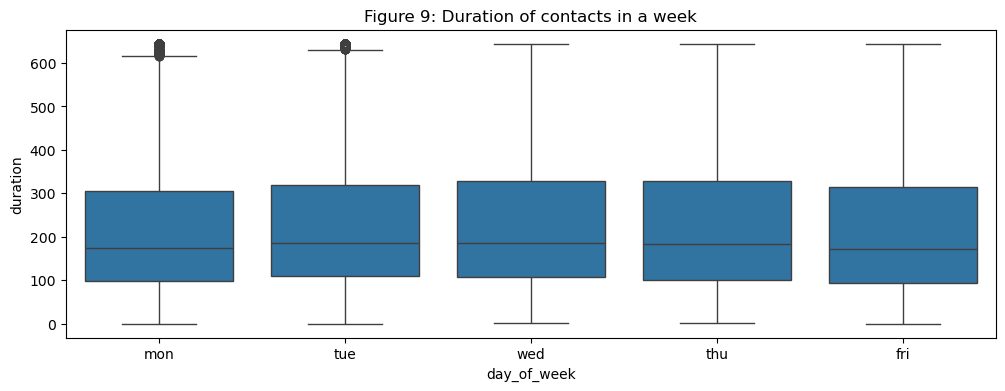

```python
plt.figure(figsize=(12, 4))
plt.title("Figure 9: Duration of contacts in a week")
sns.boxplot(x = 'day_of_week', y = 'duration', data = data)
```

This boxplot depicts the distribution of the 'duration' variable over several days of the week. Outliers are particularly prevalent on Mondays and Tuesdays, implying that these days may have longer durations than other days. This knowledge is useful for understanding contact length trends, and it may justify additional inquiry into why these outliers occur on these specific days.

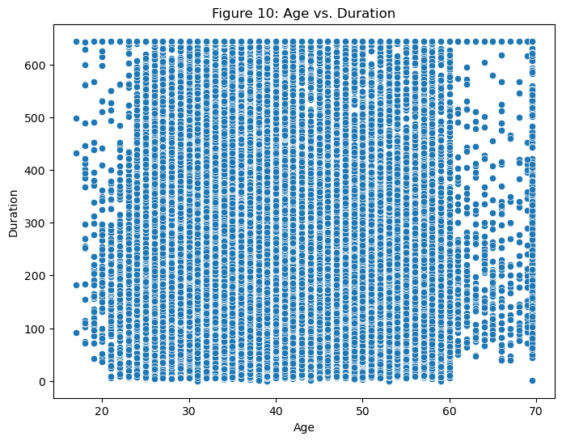

```python
# Scatter plot of age vs. duration
plt.figure(figsize=(8, 6))
sns.scatterplot(data=data, x='age', y='duration')
plt.title('Figure 10: Age vs. Duration')
plt.xlabel('Age')
plt.ylabel('Duration')
plt.show()
```

The scatterplot depicts the link between people' ages and the duration of their interactions. Each point on the figure represents one individual in the dataset, with age on the x-axis and interaction length on the y-axis.

In the scatter plot:

Individuals aged 23 to 60 years old have a wide range of interaction lengths, as seen by a dense cluster of dots creating a solid line stretching from 0 to 650 seconds on the y-axis. This shows that people in this age group have various lengths of contact. Individuals younger than 23 and older than 60 (excluding 70) have dispersed points with variable lengths of contacts. These findings suggest that interactions for people outside the major age range are more infrequent and less focused. Surprisingly, those aged 70 exhibit a similar pattern to those aged 23 to 60, with a solid line of points spanning from 0 to 650 seconds on the y-axis. This shows that people beyond the age of 70 have similar contact lengths to those in the general population. Overall, the scatter plot gives information on the distribution of interaction durations across age groups, showing potential trends or patterns in the dataset.

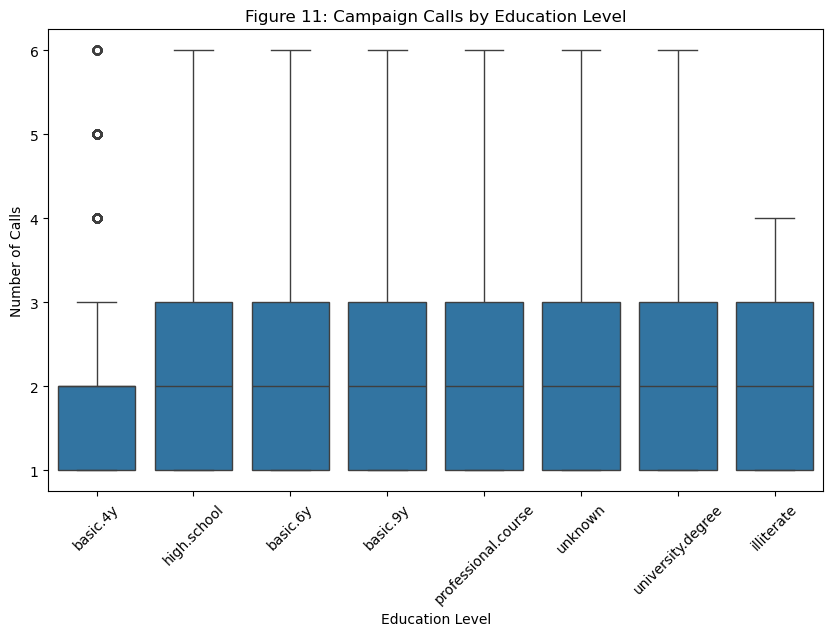

```python
# Box plot of campaign calls by education level
plt.figure(figsize=(10, 6))
sns.boxplot(data=data, x='education', y='campaign')
plt.title('Figure 11: Campaign Calls by Education Level')
plt.xlabel('Education Level')
plt.ylabel('Number of Calls')
plt.xticks(rotation=45)
plt.show()
```

The boxplot depicts the distribution of campaign calls across different education levels in the dataset. It sheds light on the variety and primary tendency of campaign calls for people with various levels of education.

For each education level:

Basic.4y: The boxplot's y-axis ranges from 1 to 2, with an upper bound of 3. Three dots appear at places 4, 5, and 6 on the y-axis, signifying outliers. The boxplot for the remaining education levels (high.school, basic.6y, basic.9y, professional.course, unknown, university.degree, and illiterate) ranges from 1 to 3 on the y-axis, with the center line set to 2. The upper bound is set at 6 for the majority of education levels, with the exception of illiteracy, which is set at 4.

This graphic compares the distribution of campaign calls across education levels, revealing possible variations or similarities in campaign involvement among people with diverse educational backgrounds.

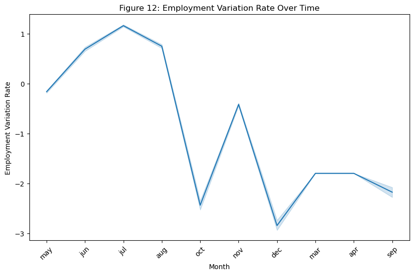

```python
# Line plot showing the trend of emp.var.rate over time
plt.figure(figsize=(10, 6))
sns.lineplot(data=data, x='month', y='emp_var_rate')
plt.title('Figure 12: Employment Variation Rate Over Time')
plt.xlabel('Month')
plt.ylabel('Employment Variation Rate')
plt.xticks(rotation=45)
plt.show()
```

The line plot depicts the trend of the employment variation rate across multiple months in the dataset, shedding light on the fluctuations and changes in employment circumstances over time.

This visualization enables the study of trends and patterns in employment variation rates over a particular time period, offering useful insights on shifts in employment circumstances over time.

### Multivariate visualization

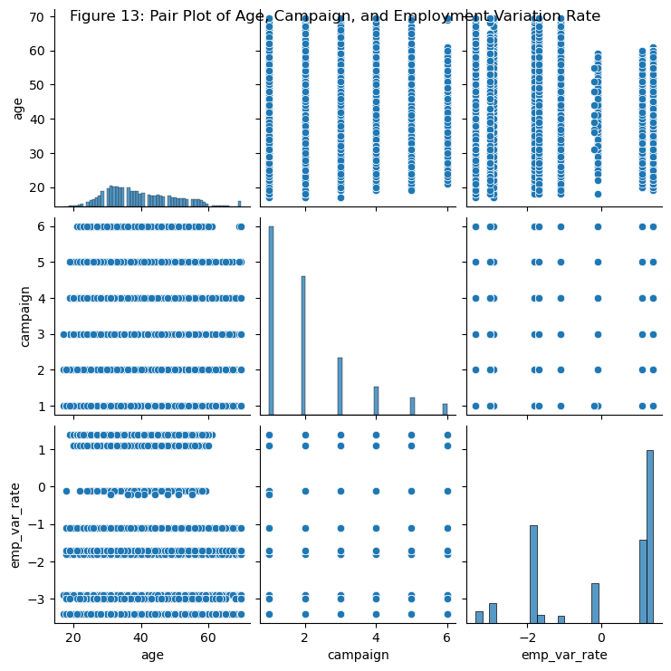

```python
# Pair plot of age, campaign, and emp.var.rate
sns.pairplot(data[['age', 'campaign', 'emp_var_rate']])
plt.suptitle('Figure 13: Pair Plot of Age, Campaign, and Employment Variation Rate')
plt.show()
```

The pair plot visualizes the associations between age, campaign, and employment variation rate throughout the dataset. It facilitates the investigation of potential connections and patterns between these variables.

The off-diagonal plots display scatter plots representing the relationships between pairs of variables:

The scatter plot between age and campaign depicts the distribution of campaign calls among various age groups. It enables the detection of any potential trends or patterns in campaign involvement depending on age. The scatter plot of age vs employment variation rate shows how employment variation rates change across age groups. It facilitates the investigation of any potential links between age and job circumstances. The scatter plot depicts the association between the number of campaign calls and employment variance rates. It enables for the investigation of possible correlations between marketing campaign activities and work situations.

Overall, the pair plot is an effective tool for displaying and evaluating the correlations between age, campaign, and job fluctuation rate, allowing for the discovery of patterns and trends within the dataset.

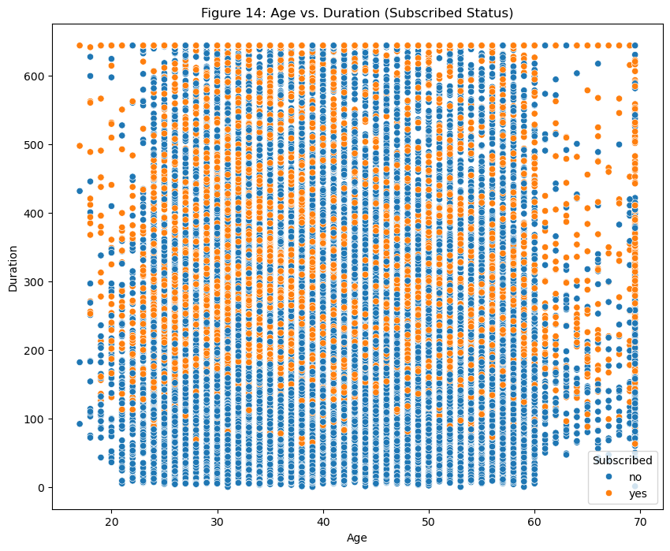

```python
# Scatter plot of age vs. duration colored by subscribed status
plt.figure(figsize=(10, 8))
sns.scatterplot(data=data, x='age', y='duration', hue='subscribed')
plt.title('Figure 14: Age vs. Duration (Subscribed Status)')
plt.xlabel('Age')
plt.ylabel('Duration')
plt.legend(title='Subscribed')
plt.show()
```

The scatter plot depicts the association between individuals' ages and the duration of their interactions, with dots colored according on their subscription status. It sheds light on possible disparities in contact lengths between subscribing and non-subscribed persons across age groups.

The plot reveals the following patterns:

Individuals aged 23 to 60 years old show a dense cluster of dots creating a solid line on the y-axis ranging from 0 to 600 seconds, indicating various interaction lengths. Individuals younger than 23 and older than 60 (excluding 70) have dispersed dots at intervals, indicating intermittent contact durations. Interestingly, those aged 70 show a pattern identical to those aged 23 to 60, with a solid line of points on the y-axis ranging from 0 to 650 seconds.

The points are colored according to subscribed status:

Subscribed users: Points are colored differently to indicate interactions in which the individual has subscribed to the service. Non-subscribed individuals: Points remain in their default color, showing interactions in which the individual has not subscribed.

Overall, the scatter plot visualizes interaction durations across age groups, providing insights on how subscriber status affects these durations.

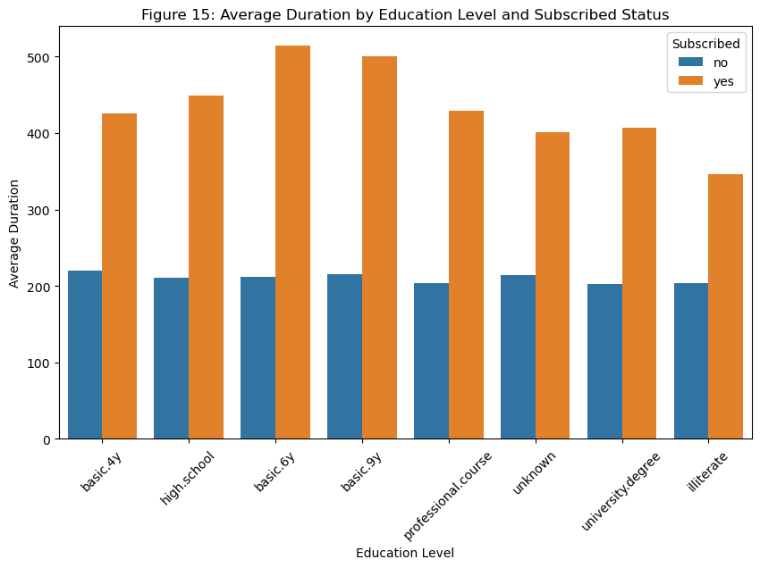

```python
# Bar plot of average duration by education level and subscribed status
plt.figure(figsize=(10, 6))
sns.barplot(data=data, x='education', y='duration', hue='subscribed', ci=None)
plt.title('Figure 15: Average Duration by Education Level and Subscribed Status')
plt.xlabel('Education Level')
plt.ylabel('Average Duration')
plt.legend(title='Subscribed')
plt.xticks(rotation=45)
plt.show()
```

The bar plot depicts the average duration of interactions grouped by education level and subscription status. It gives information on the average duration of interactions for people with varied educational backgrounds and subscription statuses.

For each education level:

Basic.4y: The blue bar stretches from 0 to around 220, representing the average time of interactions for non-subscribers, whereas the orange bar extends to approximately 420 for subscribers. High school: The blue bar runs from 0 to roughly 210, while the orange bar reaches about 450. Basic.6y: The blue bar spans from 0 to around 210, while the orange bar extends to around 520. Basic.9y: The blue bar ranges from 0 to about 220, while the orange bar reaches around 490. Professional.course: The blue bar spans from 0 to around 200, while the orange bar extends to around 415. Unknown: The blue bar spans from 0 to roughly 210, while the orange bar reaches about 400. University.degree: The blue bar extends to nearly 200, while the orange bar reaches around 410. Illiterate: The blue bar extends to roughly 210, whereas the orange bar reaches about 350.

The bars are colored differently based on subscribed status:

Blue bars reflect exchanges in which the individual did not subscribe. Orange bars indicate interactions in which the individual has subscribed.

Overall, the bar plot compares the average duration of interactions across education levels and subscriber statuses, emphasizing possible disparities in interaction durations based on these variables.

```python
# Facet grid of age vs. duration with hue as education level
g = sns.FacetGrid(data=data, col='education', col_wrap=3, height=4)
g.map(sns.scatterplot, 'age', 'duration', alpha=0.5)
g.set_axis_labels('Age', 'Duration')
g.set_titles('{col_name}')
plt.subplots_adjust(top=0.9)
g.fig.suptitle('Figure 16: Age vs. Duration by Education Level')
plt.show()
```

[output not shown]

## Summary and Conclusions

Summary:

Conclusion:

Finally, the analysis of the Bank Marketing dataset yields useful insights that may help with strategic decision-making and marketing strategy improvement. By combining demographic data, campaign success measurements, and economic indicators, the bank may optimize its targeting criteria, increase campaign efficiency, and reduce the risk of client default. Implementing data-driven initiatives based on the findings of this study can result in increased customer engagement, higher subscription rates, and, ultimately, better commercial outcomes for the financial institution.

# A Literature Review: Unveiling Direct Marketing Dynamics in Banking

Direct marketing methods have a significant impact in the banking sector, acting as a linchpin for client interaction, product promotion, and subscriber acquisition. This comprehensive literature study aims to dig into the multidimensional area of direct marketing efficacy in the banking industry, using a detailed analysis of visualizations and empirical findings to highlight key trends and essential issues. Direct marketing has emerged as a vital strategy for banks worldwide, aiming to engage customers directly through various channels. Direct marketing in banking has evolved significantly with technology, from direct mail and telemarketing it has expanded to include emails, SMS, social media and personalized digital experiences. Banks also employ strategies such as segmentation and personalization which allows institutions to tailor messages according to customer demographics, behaviors and preferences. It can also foster stronger relationships between customers and banks by delivering timely and personalized communications. Miguéis, V.L., Camanho, A.S. & Borges(2017)

## 1. Interpreting Customer Demographics and Response Dynamics

Understanding the complex interplay between consumer demographics and reaction habits is at the heart of good direct marketing. Visualizations, like as scatter plots and bar charts, provide insight into the many features of banking customers and their complex responses to marketing stimuli. Distinct patterns appear when age cohorts are compared to interaction durations, demonstrating variable degrees of involvement across generational divisions. Furthermore, bar graphs showing the average duration of contacts stratified by educational attainment and subscription status reveal differences in preferences and inclinations across demographic strata. With consumers interacting across multiple channels, banks must ensure a seamless experience across all points. Omnichannel integration enables banks to maintain consistency in their messaging, regardless of the channel using by the customer.

## 2. Deciphering Campaign Outcomes and Channel Proficiency

The success of direct marketing efforts is determined by its ability to provide concrete results and harness the most effective channels for consumer outreach. Box plots and line plots have emerged as vital tools for reviewing campaign success data and determining the efficiency of various marketing channels. By examining the distribution of campaign calls across educational backgrounds, stakeholders may receive insight into the resonance of marketing appeals across various audience segments. Concurrently, longitudinal evaluations of employment fluctuation rates provide contextual awareness, allowing practitioners to connect marketing efforts with current economic developments and consumer attitude.

## 3. Navigating Ethical Imperatives and Privacy Imperatives

In an era dominated by data-driven marketing paradigms, ethical issues and privacy imperatives take precedence in the banking sector. Compliance with data privacy regulations and ethical data practices will remain a top priority to banks. Proactively addressing regulatory requirements and maintaining transparency in data usage will be essential to building and maintaining trust with the customers. Visualizations, such as scatter plots and box plots, provide as a channel for highlighting ethical quandaries and regulatory compliance obligations inherent in modern marketing tactics. Ethical data management and strict privacy policies are non-negotiable elements for building trust and long-term consumer relationships. Regulatory regulations, such as the GDPR and CCPA, require strong data governance procedures, forcing banks to be cautious in their use of client data for marketing. Additionally, the marketing messages sprouting across multiple channels raises the risk of customer fatigue and opt-out rates.

## Synthesis and Future Trajectories

This comprehensive assessment emphasizes the critical role of direct marketing in shaping the banking landscape, igniting consumer engagement, and driving subscription outcomes. Visualizations emerge as vital tools for deciphering detailed patterns, identifying new trends, and defining strategic imperatives in the financial environment. Banks may adapt their marketing tactics to better resonate with varied client categories while adhering to ethical values and legal obligations. Key strategies like segmentation, targeting and personalization has enabled banks to deliver more relevant and personalized marketing messages

Several trajectories will shape the future of direct marketing:

- Data Analytics and AI: Banks will increasingly leverage advanced data analytics and AI driven insights to enhance their direct marketing efforts. Predictive analysis can help banks anticipate customer needs.
- Automation: Automation technologies such as virtual assistants like chatbots will deliver personalized recommendations, assist with customer inquiries and streamline the customer journey enhancing engagement and efficiency.
- Augmented reality: AR technologies have the potential to revolutionize direct marketing by creating immersive and interactive experiences for customers. Banks can use AR applications to showcase products, to simulate financial scenarios and engage customers in innovative ways which will boost the marketing further.
- Personalized Wellness Programs: Banks can develop wellness programs which can go beyond traditional marketing campaigns by offering tailored advice, services, tools and resources to help customers achieve their financial goals while strengthening loyalty and engagement.
- Blockchain technology: Blockchain technologies now offers better data security and transparency by leveraging solutions to enhance the integrity of customer data, addressing concerns around data privacy and security.

## Conclusion

In conclusion, the convergence of visuals and empirical findings serves as a guidepost for traversing the perplexing landscape of direct marketing in the banking industry. By clarifying the delicate interplay between client demographics, campaign outcomes, and ethical issues, this literature review provides stakeholders with a comprehensive perspective for developing effective marketing strategies. As the financial sector evolves in parallel with technology breakthroughs and changing customer tastes, the importance of data-driven decision-making and ethical stewardship remains paramount. Carson, D., Gilmore, A., & Walsh, S. (2004)

## Future Research Directions

Looking ahead, further study might dive deeper into a variety of pathways to improve our understanding of direct marketing dynamics in banking. Investigating the influence of developing technologies, such as artificial intelligence and machine learning, on marketing customization and consumer segmentation may provide significant insights for enhancing marketing strategy. Furthermore, studying the impact of social media platforms and digital channels in supplementing traditional marketing strategies may reveal new opportunities for customer involvement and brand promotion, longitudinal studies that follow the evolution of customer preferences and market trends over time may give essential insight for modifying marketing tactics to suit changing consumer expectations. Hyper personalization using data analytics can enhance the relevance and effectiveness of direct marketing campaigns.

## References

Dataset Reference:

1. Moro,S., Rita,P., and Cortez,P.. (2012). Bank Marketing. UCI Machine Learning Repository. https://doi.org/10.24432/C5K306.

Data Visualization reference:

1. GeeksforGeeks. (2024). Graph plotting in Python: Set 1. https://www.geeksforgeeks.org/graph-plotting-in-python-set-1/

Journal Article references:

1. Ahmed Mohamed Zaki, Nima Khodadadi, Wei Hong Lim, S. K. Towfek. (2024). Predictive Analytics and Machine Learning in Direct Marketing for Anticipating Bank Term Deposit Subscriptions. Journal of American Journal of Business and Operations Research, 11 ( 1 ), 79-88 (Doi : https://doi.org/10.54216/AJBOR.110110)
2. Miguéis, V.L., Camanho, A.S. & Borges, J. Predicting direct marketing response in banking: comparison of class imbalance methods. Serv Bus 11, 831–849 (2017). https://doi.org/10.1007/s11628-016-0332-3
3. Debling, F. ‘On-brand banking’: An examination of the factors contributing to effective branding and brand development through direct marketing in the consumer financial services sector. J Financ Serv Mark 5, 150–173 (2000). https://doi.org/10.1057/palgrave.fsm.4770015
4. Moro, S., Cortez, P., & Rita, P. (2014). A data-driven approach to predict the success of bank telemarketing. Decis. Support Syst., 62, 22-31.
5. Carson, D., Gilmore, A., & Walsh, S. (2004). Balancing Transaction and Relationship Marketing in Retail Banking. Journal of Marketing Management, 20(3–4), 431–455. https://doi.org/10.1362/026725704323080489
6. Chang, C.-W., & Zhang, J. Z. (2016). The Effects of Channel Experiences and Direct Marketing on Customer Retention in Multichannel Settings. Journal of Interactive Marketing, 36(1), 77-90. https://doi.org/10.1016/j.intmar.2016.05.002
7. Lund, D. J., & Marinova, D. (2014). Managing Revenue across Retail Channels: The Interplay of Service Performance and Direct Marketing. Journal of Marketing, 78(5), 99-118. https://doi.org/10.1509/jm.13.0220
8. Sundararajan, R., Bhaskar, T., Sarkar, A., Dasaratha, S., Bal, D., Marasanapalle, J. K., Zmudzka, B., & Bak, K. (2011). Marketing Optimization in Retail Banking. Interfaces, 41(5), 485–505. http://www.jstor.org/stable/41318834
9. Dolnicar, S., & Jordaan, Y. (2007). A Market-Oriented Approach to Responsibly Managing Information Privacy Concerns in Direct Marketing. Journal of Advertising, 36(2), 123–149. https://doi.org/10.2753/JOA0091-3367360209
10. Garepasha, A., Aali, S., Bafandeh Zendeh, A.R. and Iranzadeh, S. (2021), "Relationship dynamics in customer loyalty to online banking services", Journal of Islamic Marketing, Vol. 12 No. 4, pp. 830-863. https://doi.org/10.1108/JIMA-09-2019-0183

Conference paper references:

1. Ardrey, W., Karunaratna, A., Keane, M. Entrepreneurship, innovation, incumbency in Vietnam's turbulent financial sector: bank marketing and strategy implications for private sector challengers, Proceedings of ANZMAC 2003 Conference, 2003 / Rachel Kennedy, (ed./s), pp.818-823
2. Harrison, T. (2003), "Understanding the behaviour of financial services consumers: A research agenda", Journal of Financial Services Marketing, Vol. 8 No. 1, pp. 6-9
3. Liang, C.J. and Wang, W.H. (2007), "An insight into the impact of a retailer's relationship efforts on customers' attitudes and behavioral intentions", International Journal of Bank Marketing, Vol. 25 No. 5, pp. 336-366.
4. Batra, R. and Ray, M.L. (1986), "Affective responses mediating acceptance of advertising", Journal of Consumer Research, Vol. 13 No. 2, pp. 234-249.